# PEC3-Hilo Argumental

```r
#install.packages("kableExtra")
```

```r
library(rockchalk)
library(nortest)
library(normtest)
library(moments)
library(car)
```

```r
library(ggplot2)
library(dplyr)
```

El objetivo de este documento no es otro que la realización mas exhaustiva del analisis de las variables que hemos considerado para poder esclarecer si las medidas que actualmente esta tomando el ayuntamiento de Madrid va a llevar a esta ciudad al camino de sostenibilidad y que este nos sirva de hilo argumental para el artículo de investigación final. Los datos son adquiridos desde el portal de datos abiertos del ayuntamiento de Madrid.

**1.Coddistri**: Representa el código de cada uno de los distrito de Madrid.

**2. Nombredistri**: Nombre de cada uno de los distrito de Madrid.

**3. Numbarrios**: Número de barrios por cada uno de los distritos de Madrid.

**4. Superficie**: Superficie en hectareas por cada uno de los distrito de Madrid.

**5. ConsumoAgua**: Consumo medio de agua por habitante en cada uno de los distritos.

**6. Natalidad**: Natalidad por distrito.

**7. Mortalidad**: Mortalidad por distrito.

**8. IndPobAct**: Indice de población activa por distrito.

**9. Poblacion**: Población por distritos.

**10.NumCentSan**: Número de centros sanitarios de salud por distrito.

**11.NumAparc**: Número de aparcabicis por distrito.

**12.Numptolim**: Número de punto limpios de proximidad por distrito.

**13.Numptosrecargas**: Número de puntos de recargas eléctricas por distrito.

**14.NumInmu**: Número de inmuebles por distrito.

**15.SupfCons**: Superfice construida por distrito.

**16.HcVerdes**: Hectareas verdes por distritos.

Localizamos la ruta donde debe estar el fichero que contine los datos

```r
getwd()
```

```
## [1] "C:/Users/David&Sonix/Downloads/Periodismo de Datos/Ficheros Transformados"
```

Procedemos a leer el fichero *PEC3HiloArgumental.csv*. La carga la hacemos con read.csv2 ya que ; (punto y coma) es el separador de las variables y , (coma) el de los decimales.

```r
madrid<-read.csv2("PEC3HiloArgumental.csv",sep=";",dec=",",na.strings = "NA")
#Mostramos las primeras filas
head(madrid)
```

```
##   Coddistri         Nombredistri Numbarrios Superficie ConsumoAgua
## 1         1 CENTRO                        6    5231264     8256783
## 2         2 ARGANZUELA                    7    6466400     6588983
## 3         3 RETIRO                        6    5465307     5563420
## 4         4 SALAMANCA                     6    5387243     7919520
## 5         5 CHAMARTIN                     6    9170122     7687755
## 6         6 TETUAN                        6    5388121     7063199
##   Natalidad Mortalidad IndPobAct Poblacion NumCentSan NumAparc Numptolim
## 1      7.32       7.93     36.16    132352          7       75         3
## 2      9.11       8.36     48.44    152907          9       45         0
## 3      8.39      10.02     43.54    119011          4       40         0
## 4      8.25      10.32     47.25    145268          8       44         0
## 5      9.95       9.66     50.87    144894          7       53         0
## 6      9.18       9.35     54.91    155967          6       40         0
##   Numptosrecargas NumInmu SupfCons HcVerdes
## 1               4   20498  2546949    44.87
## 2               2   28163  2871043   129.71
## 3               4   41859  3955626   154.15
## 4               7   47213  4834921    43.42
## 5               3   53999  8357046    56.13
## 6               0   54365  6373753    65.30
```

Observamos los nombres de las columnas

```r
#Nombres de las columnas
colnames(madrid)
```

```
##  [1] "Coddistri"       "Nombredistri"    "Numbarrios"
##  [4] "Superficie"      "ConsumoAgua"     "Natalidad"
##  [7] "Mortalidad"      "IndPobAct"       "Poblacion"
## [10] "NumCentSan"      "NumAparc"        "Numptolim"
## [13] "Numptosrecargas" "NumInmu"         "SupfCons"
## [16] "HcVerdes"
```

Mostrasmos algunos detalles

```r
#Detalles del variables
str(madrid)
```

```
## 'data.frame':    21 obs. of  16 variables:
##  $ Coddistri      : int  1 2 3 4 5 6 7 8 9 10 ...
##  $ Nombredistri   : Factor w/ 21 levels "ARGANZUELA          ",..: 4 1 14 15 5 17 6 8 11 10 ...
##  $ Numbarrios     : int  6 7 6 6 6 6 6 8 7 7 ...
##  $ Superficie     : int  5231264 6466400 5465307 5387243 9170122 5388121 4674105 237810357 46531134 25417269 ...
##  $ ConsumoAgua    : int  8256783 6588983 5563420 7919520 7687755 7063199 7701358 11146898 7208250 9765720 ...
##  $ Natalidad      : num  7.32 9.11 8.39 8.25 9.95 ...
##  $ Mortalidad     : num  7.93 8.36 10.02 10.32 9.66 ...
##  $ IndPobAct      : num  36.2 48.4 43.5 47.2 50.9 ...
##  $ Poblacion      : int  132352 152907 119011 145268 144894 155967 138418 242928 117835 235785 ...
##  $ NumCentSan     : int  7 9 4 8 7 6 7 10 8 14 ...
##  $ NumAparc       : int  75 45 40 44 53 40 62 69 44 39 ...
##  $ Numptolim      : int  3 0 0 0 0 0 1 0 2 0 ...
##  $ Numptosrecargas: int  4 2 4 7 3 0 7 1 0 0 ...
##  $ NumInmu        : int  20498 28163 41859 47213 53999 54365 55179 58653 66022 66869 ...
##  $ SupfCons       : int  2546949 2871043 3955626 4834921 8357046 6373753 5123023 5196427 6757374 8548212 ...
##  $ HcVerdes       : num  44.9 129.7 154.2 43.4 56.1 ...
```

Comprobamos que el número de filas o registros cargados son correctos

```r
#Número de filas del fichero
nrow(madrid)
```

```
## [1] 21
```

Las caracteristicas anteriores las observarmos para comprobar si el fichero se ha subido adecuadamente.

Observamos el tipo de variable que R ha asignado, es habitual que no asigne el adecuado.

```r
sapply(madrid, class)
```

```
##       Coddistri    Nombredistri      Numbarrios      Superficie
##       "integer"        "factor"       "integer"       "integer"
##     ConsumoAgua       Natalidad      Mortalidad       IndPobAct
##       "integer"       "numeric"       "numeric"       "numeric"
##       Poblacion      NumCentSan        NumAparc       Numptolim
##       "integer"       "integer"       "integer"       "integer"
## Numptosrecargas         NumInmu        SupfCons        HcVerdes
##       "integer"       "integer"       "integer"       "numeric"
```

Modificamos la clase de la variable Coddistri ya que la vamos a considerar tambien como factor en lugar de integer

```r
madrid$Coddistri=as.factor(madrid$Coddistri)
```

Comprobamos ahora la clase de la variable Coddistri

```r
class(madrid$Coddistri)
```

```
## [1] "factor"
```

En este caso salvo *Coddistri* y *Nombredistri* el resto de variables son cuantitativas.

Si algunas de estas variables tiene el valor cero esto indicara una representación correcta de la carencia de dato pero si este es vacio indicara valor perdido. En el momento de la lectura del fichero se ha especificado *na.strings=“NA”* con lo cual, cualquier elemento vacio ha sido rellenado con “NA”. Comprobamos que variables tiene datos perdidos y valores ceros

```r
#En el momento de la lectura del fichero establecemos
#que si se encuenta un valor perdido los asigne por Na (na.strings = "NA")
table(is.na(madrid$Numbarrios))
```

```
##
## FALSE
##    21
```

```r
madrid$Numbarrios[which(madrid$Numbarrios==0)]
```

```
## integer(0)
```

```r
table(is.na(madrid$Superficie))
```

```
##
## FALSE
##    21
```

```r
madrid$Superficie[which(madrid$Superficie==0)]
```

```
## integer(0)
```

```r
table(is.na(madrid$ConsumoAgua))
```

```
##
## FALSE
##    21
```

```r
madrid$ConsumoAgua[which(madrid$ConsumoAgua==0)]
```

```
## integer(0)
```

```r
table(is.na(madrid$Natalidad))
```

```
##
## FALSE
##    21
```

```r
madrid$Natalidad[which(madrid$Natalidad==0)]
```

```
## numeric(0)
```

```r
table(is.na(madrid$Mortalidad))
```

```
##
## FALSE
##    21
```

```r
madrid$Mortalidad[which(madrid$Mortalidad==0)]
```

```
## numeric(0)
```

```r
table(is.na(madrid$IndPobAct))
```

```
##
## FALSE
##    21
```

```r
madrid$IndPobAct[which(madrid$IndPobAct==0)]
```

```
## numeric(0)
```

```r
table(is.na(madrid$Poblacion))
```

```
##
## FALSE
##    21
```

```r
madrid$Poblacion[which(madrid$Poblacion==0)]
```

```
## integer(0)
```

```r
table(is.na(madrid$NumCentSan))
```

```
##
## FALSE
##    21
```

```r
madrid$NumCentSan[which(madrid$NumCentSan==0)]
```

```
## integer(0)
```

```r
table(is.na(madrid$NumAparc))
```

```
##
## FALSE
##    21
```

```r
madrid$NumAparc[which(madrid$NumAparc==0)]
```

```
## integer(0)
```

```r
table(is.na(madrid$Numptolim))
```

```
##
## FALSE
##    21
```

```r
madrid$Numptolim[which(madrid$Numptolim==0)]
```

```
##  [1] 0 0 0 0 0 0 0 0 0 0 0 0 0 0
```

```r
table(is.na(madrid$Numptosrecargas))
```

```
##
## FALSE
##    21
```

```r
madrid$Numptosrecargas[which(madrid$Numptosrecargas==0)]
```

```
## [1] 0 0 0 0 0 0 0 0 0
```

```r
table(is.na(madrid$NumInmu))
```

```
##
## FALSE
##    21
```

```r
madrid$NumInmu[which(madrid$NumInmu==0)]
```

```
## integer(0)
```

```r
table(is.na(madrid$SupfCons))
```

```
##
## FALSE
##    21
```

```r
madrid$SupfCons[which(madrid$SupfCons==0)]
```

```
## integer(0)
```

```r
table(is.na(madrid$HcVerdes))
```

```
##
## FALSE
##    21
```

```r
madrid$HcVerdes[which(madrid$HcVerdes==0)]
```

```
## numeric(0)
```

Veamos tambien si las variables *Coddistri* y *Nombredistri* tienen valores perdidos

```r
table(is.na(madrid$Coddistri))
```

```
##
## FALSE
##    21
```

```r
table(is.na(madrid$Nombredistri))
```

```
##
## FALSE
##    21
```

Podemos concluir que ninguna de las variables tienen valores perdidos. Pero las variables *Numptosrecargas* y *Numptolim* si toman valores cero, lo cual parece correcto ya que no todos los distritos tienen por que tener hoy por hoy ni puntos de recargas eléctricos ni puntos limpios de proximidad.

Se considera dato atípico como una observación fuera de la normalidad de la variable, una observación con una desviación tan grande del resto de observaciones que incluso se puede cuestionar si se ha obtenido por los mismos medios que las anteriores. El punto común es ver lo alejado que esta del resto de las observaciones de la variable. Los datos atípicos pueden tener efectos perligroso en los análisis estadísticos se puede llegar aumentar el error de la varianza y no obtener unos resultados oportunos para las pruebas estadísticas que realicemos.

Realizamos un estudio de cada una de las variables

**Numbarrios**

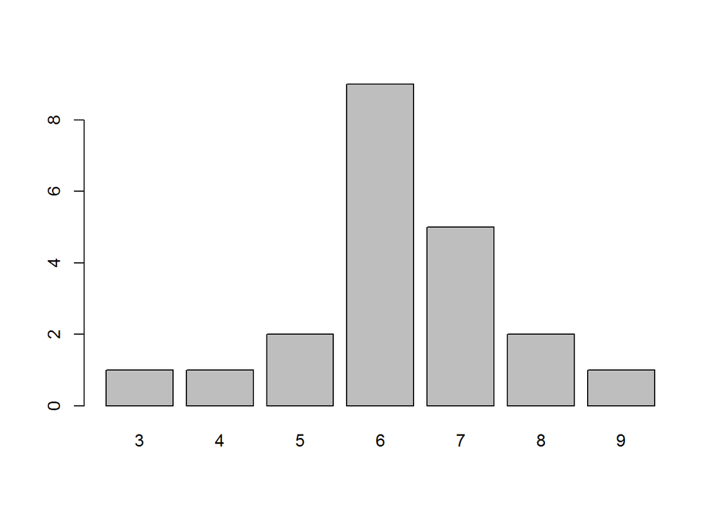

```r
#grafico de frecuencia
barplot(table(madrid$Numbarrios))
```

```r
#resumen de los valores mas significativos
summary(madrid$Numbarrios)
```

```
##    Min. 1st Qu.  Median    Mean 3rd Qu.    Max.
##   3.000   6.000   6.000   6.238   7.000   9.000
```

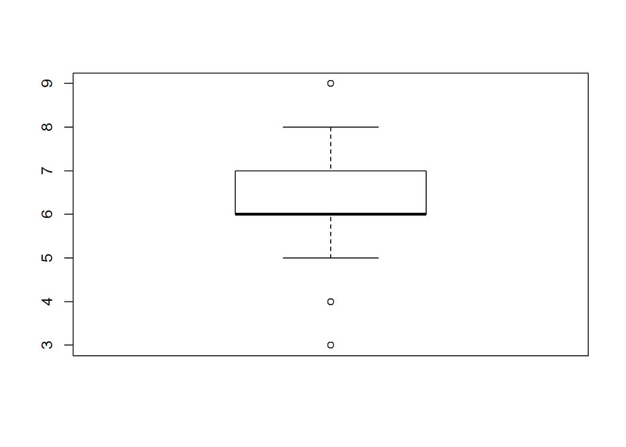

```r
#grafica boxplot
boxplot(madrid$Numbarrios)
```

```r
#Media Aritmetica
Media_Numbarrios<-mean(madrid$Numbarrios)
#Mediana
Mediana_Numbarrios<-median(madrid$Numbarrios)
#Media Recortada
Media_Recortada_Numbarrios<-mean(madrid$Numbarrios, trim=0.05)
#Desviación estándar
Desviacion_estandar_Numbarrios<-sd(madrid$Numbarrios)
#Rango Intercuartilico (RIC)
RIC_Numbarrios<-IQR(madrid$Numbarrios)
#Desviación Absoluta Respecto de la Mediana
Desviacion_Absoluta_Mediana_Numbarrios<-mad(madrid$Numbarrios)
#Tabla
kable(rbind(Media_Numbarrios,Mediana_Numbarrios,Media_Recortada_Numbarrios,
Desviacion_estandar_Numbarrios,RIC_Numbarrios,
Desviacion_Absoluta_Mediana_Numbarrios))
```

| Media_Numbarrios | 6.238095 |
| --- | --- |
| Mediana_Numbarrios | 6.000000 |
| Media_Recortada_Numbarrios | 6.263158 |
| Desviacion_estandar_Numbarrios | 1.338087 |
| RIC_Numbarrios | 1.000000 |
| Desviacion_Absoluta_Mediana_Numbarrios | 1.482600 |

Podemos afirmar que el número de barrios por distrito varia desde 5 hasta 8 y que el 50% de los distritos tienen como número de barrios entre 6 y 7. Ademas hay 2 distritos cuyo numero de barrios esta por debajo de 5 y uno que esta por encima de 8.

**Superficie**

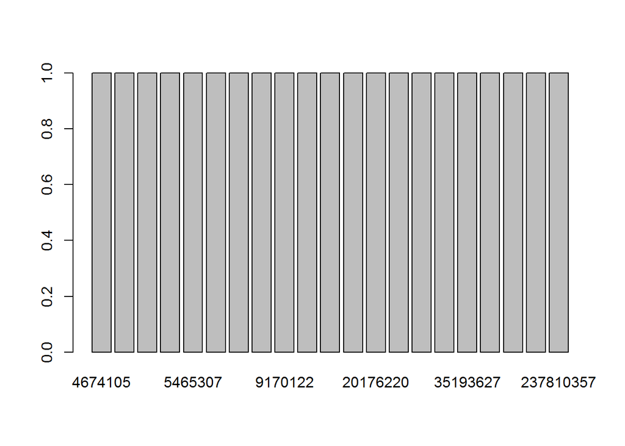

```r
#grafico de frecuencia
barplot(table(madrid$Superficie))
```

```r
#resumen de los valores mas significativos
summary(madrid$Superficie)
```

```
##      Min.   1st Qu.    Median      Mean   3rd Qu.      Max.
##   4674105   6110071  14048399  28779376  27414593 237810357
```

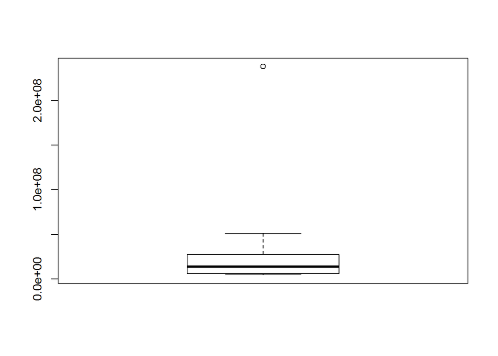

```r
#grafica boxplot
boxplot(madrid$Superficie)
```

```r
#Media Aritmetica
Media_Superficie<-mean(madrid$Superficie)
#Mediana
Mediana_Superficie<-median(madrid$Superficie)
#Media Recortada
Media_Recortada_Superficie<-mean(madrid$Superficie, trim=0.05)
#Desviación estándar
Desviacion_estandar_Superficie<-sd(madrid$Superficie)
#Rango Intercuartilico (RIC)
RIC_Superficie<-IQR(madrid$Superficie)
#Desviación Absoluta Respecto de la Mediana
Desviacion_Absoluta_Mediana_Superficie<-mad(madrid$Superficie)
#Tabla
kable(rbind(Media_Superficie,Mediana_Superficie,Media_Recortada_Superficie,
Desviacion_estandar_Superficie,RIC_Superficie,
Desviacion_Absoluta_Mediana_Superficie))
```

| Media_Superficie | 28779376 |
| --- | --- |
| Mediana_Superficie | 14048399 |
| Media_Recortada_Superficie | 19046443 |
| Desviacion_estandar_Superficie | 50091407 |
| RIC_Superficie | 21304522 |
| Desviacion_Absoluta_Mediana_Superficie | 12839728 |

Se puede observar como cada distrito tiene una superficie diferente y que unicamente uno de ellos tiene una superficie superior a los demas.

**ConsumoAgua**

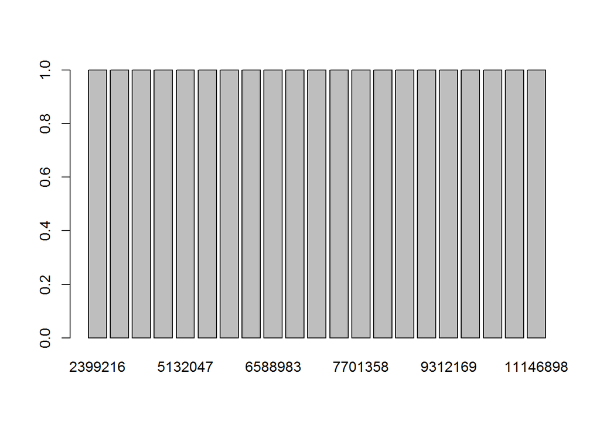

```r
#grafico de frecuencia
barplot(table(madrid$ConsumoAgua ))
```

```r
#resumen de los valores mas significativos
summary(madrid$ConsumoAgua )
```

```
##     Min.  1st Qu.   Median     Mean  3rd Qu.     Max.
##  2399216  5472018  7208250  7027336  8902755 11146898
```

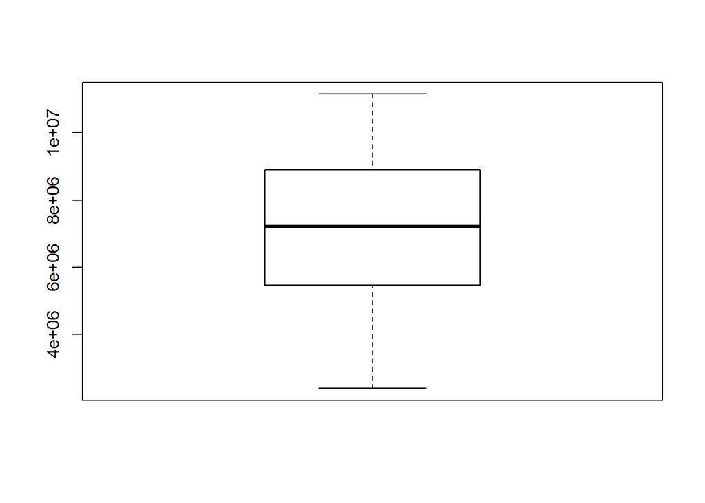

```r
#grafica boxplot
boxplot(madrid$ConsumoAgua )
```

```r
#Media Aritmetica
Media_ConsumoAgua <-mean(madrid$ConsumoAgua )
#Mediana
Mediana_ConsumoAgua <-median(madrid$ConsumoAgua )
#Media Recortada
Media_Recortada_ConsumoAgua <-mean(madrid$ConsumoAgua , trim=0.05)
#Desviación estándar
Desviacion_estandar_ConsumoAgua <-sd(madrid$ConsumoAgua )
#Rango Intercuartilico (RIC)
RIC_ConsumoAgua <-IQR(madrid$ConsumoAgua )
#Desviación Absoluta Respecto de la Mediana
Desviacion_Absoluta_Mediana_ConsumoAgua <-mad(madrid$ConsumoAgua )
#Tabla
kable(rbind(Media_ConsumoAgua ,Mediana_ConsumoAgua ,Media_Recortada_ConsumoAgua ,
Desviacion_estandar_ConsumoAgua ,RIC_ConsumoAgua ,
Desviacion_Absoluta_Mediana_ConsumoAgua ))
```

| Media_ConsumoAgua | 7027336 |
| --- | --- |
| Mediana_ConsumoAgua | 7208250 |
| Media_Recortada_ConsumoAgua | 7054102 |
| Desviacion_estandar_ConsumoAgua | 2435546 |
| RIC_ConsumoAgua | 3430737 |
| Desviacion_Absoluta_Mediana_ConsumoAgua | 2574138 |

El consumo de agua por habitante en cada distrito es unico. No existe un consumo ni por exceso ni por defecto de ninguno de ellos que llame la atención.

**Natalidad**

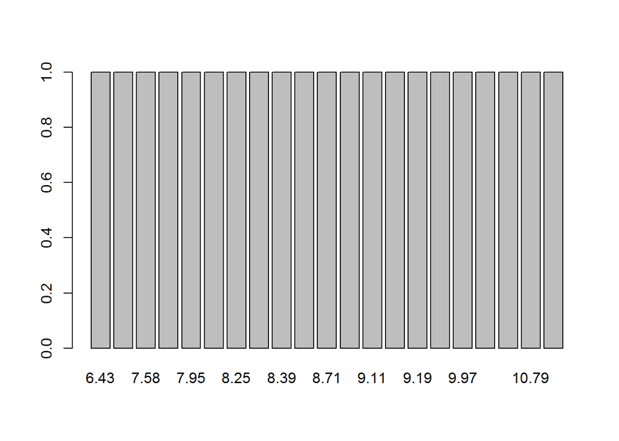

```r
#grafico de frecuencia
barplot(table(madrid$Natalidad ))
```

```r
#resumen de los valores mas significativos
summary(madrid$Natalidad )
```

```
##    Min. 1st Qu.  Median    Mean 3rd Qu.    Max.
##   6.430   8.020   8.710   9.019   9.950  14.070
```

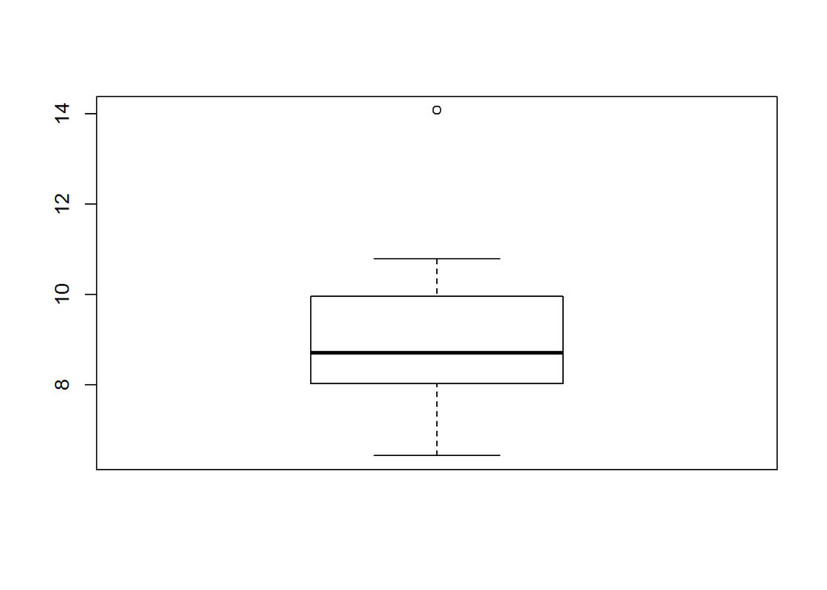

```r
#grafica boxplot
boxplot(madrid$Natalidad )
```

```r
#Media Aritmetica
Media_Natalidad <-mean(madrid$Natalidad )
#Mediana
Mediana_Natalidad <-median(madrid$Natalidad )
#Media Recortada
Media_Recortada_Natalidad <-mean(madrid$Natalidad , trim=0.05)
#Desviación estándar
Desviacion_estandar_Natalidad <-sd(madrid$Natalidad )
#Rango Intercuartilico (RIC)
RIC_Natalidad <-IQR(madrid$Natalidad )
#Desviación Absoluta Respecto de la Mediana
Desviacion_Absoluta_Mediana_Natalidad <-mad(madrid$Natalidad )
#Tabla
kable(rbind(Media_Natalidad ,Mediana_Natalidad ,Media_Recortada_Natalidad ,
Desviacion_estandar_Natalidad ,RIC_Natalidad ,
Desviacion_Absoluta_Mediana_Natalidad ))
```

| Media_Natalidad | 9.019048 |
| --- | --- |
| Mediana_Natalidad | 8.710000 |
| Media_Recortada_Natalidad | 8.889474 |
| Desviacion_estandar_Natalidad | 1.602701 |
| RIC_Natalidad | 1.930000 |
| Desviacion_Absoluta_Mediana_Natalidad | 1.126776 |

El indice de natalidad de los distritos se encuentran desde 6.43 hasta aproximadamente 11. Situandose el 50% entre 8 y 10 aproximadamente. Existe un distrito cuyo indice de natalidad se dispara.

**Mortalidad**

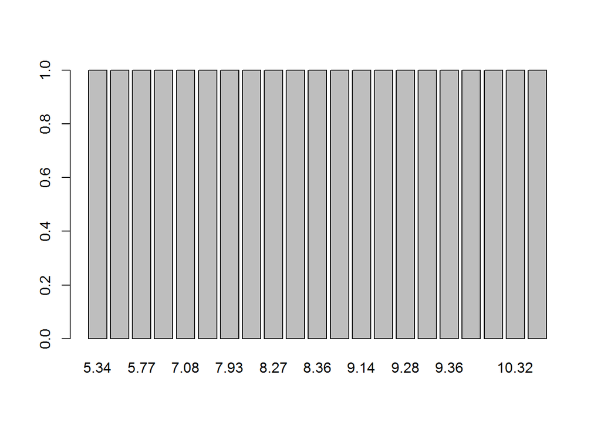

```r
#grafico de frecuencia
barplot(table(madrid$Mortalidad  ))
```

```r
#resumen de los valores mas significativos
summary(madrid$Mortalidad  )
```

```
##    Min. 1st Qu.  Median    Mean 3rd Qu.    Max.
##   5.340   7.330   8.360   8.291   9.350  10.410
```

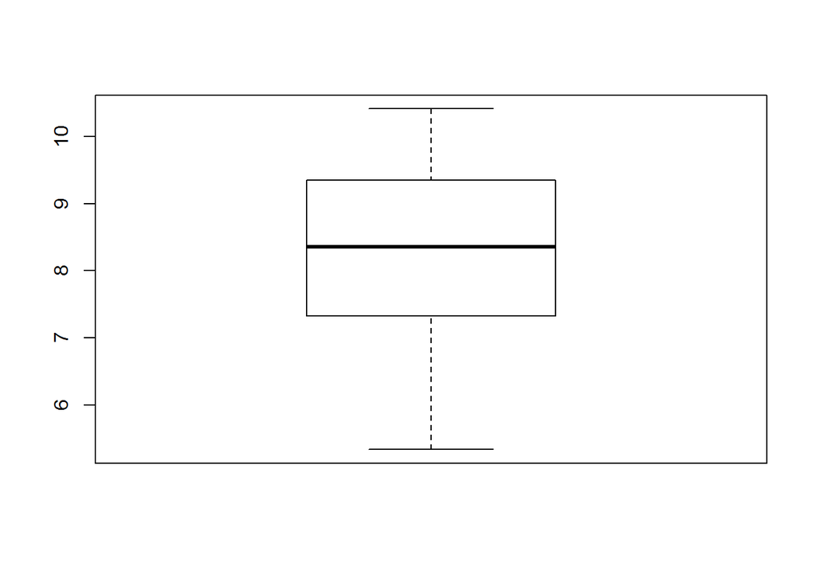

```r
#grafica boxplot
boxplot(madrid$Mortalidad  )
```

```r
#Media Aritmetica
Media_Mortalidad  <-mean(madrid$Mortalidad  )
#Mediana
Mediana_Mortalidad  <-median(madrid$Mortalidad  )
#Media Recortada
Media_Recortada_Mortalidad  <-mean(madrid$Mortalidad  , trim=0.05)
#Desviación estándar
Desviacion_estandar_Mortalidad  <-sd(madrid$Mortalidad  )
#Rango Intercuartilico (RIC)
RIC_Mortalidad  <-IQR(madrid$Mortalidad  )
#Desviación Absoluta Respecto de la Mediana
Desviacion_Absoluta_Mediana_Mortalidad  <-mad(madrid$Mortalidad  )
#Tabla
kable(rbind(Media_Mortalidad  ,Mediana_Mortalidad  ,Media_Recortada_Mortalidad  ,
Desviacion_estandar_Mortalidad  ,RIC_Mortalidad  ,
Desviacion_Absoluta_Mediana_Mortalidad  ))
```

| Media_Mortalidad | 8.290952 |
| --- | --- |
| Mediana_Mortalidad | 8.360000 |
| Media_Recortada_Mortalidad | 8.334737 |
| Desviacion_estandar_Mortalidad | 1.518552 |
| RIC_Mortalidad | 2.020000 |
| Desviacion_Absoluta_Mediana_Mortalidad | 1.482600 |

El indice de mortalidad en los distritos de Madrid se encuentran entre 5.34 y 10.41. El 50% de los distritos tienen un indice de mortalidad entre 7.25 y 9.25 aproximadamente. No existe ningún distrito que llame la atención por tener este indice ni muy bajo ni muy alto.

**IndPobAct**

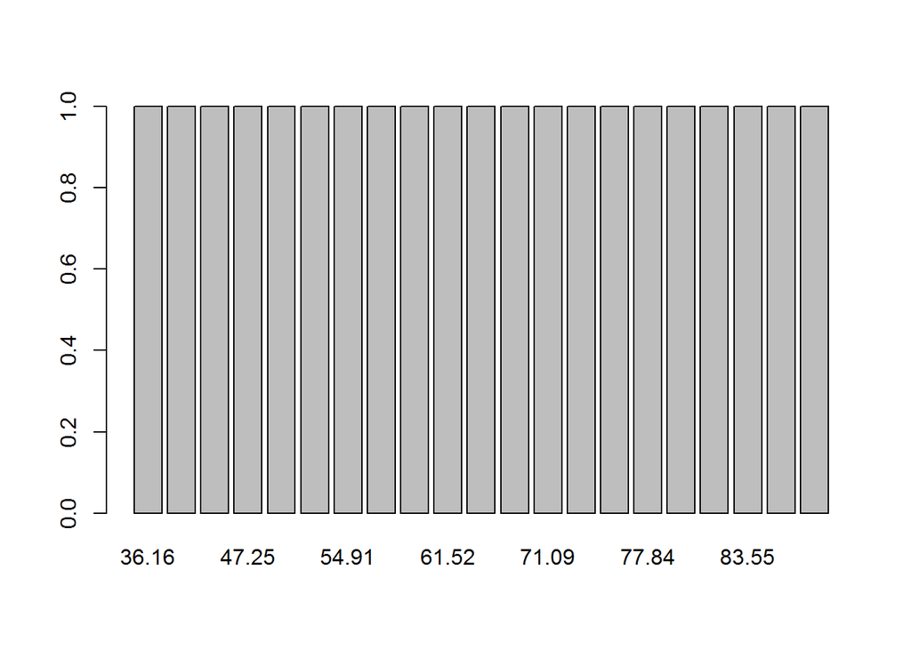

```r
#grafico de frecuencia
barplot(table(madrid$IndPobAct ))
```

```r
#resumen de los valores mas significativos
summary(madrid$IndPobAct )
```

```
##    Min. 1st Qu.  Median    Mean 3rd Qu.    Max.
##   36.16   50.87   64.68   65.49   77.84  111.44
```

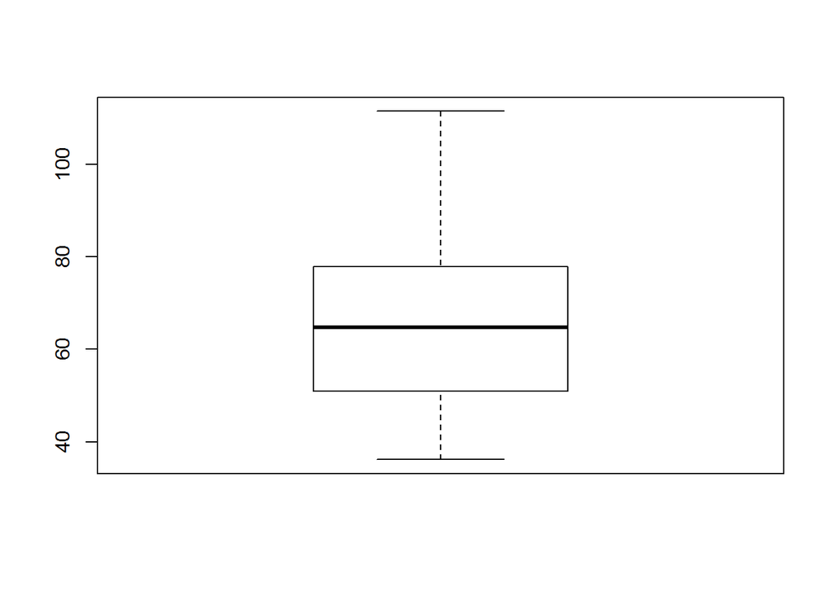

```r
#grafica boxplot
boxplot(madrid$IndPobAct )
```

```r
#Media Aritmetica
Media_IndPobAct <-mean(madrid$IndPobAct )
#Mediana
Mediana_IndPobAct <-median(madrid$IndPobAct )
#Media Recortada
Media_Recortada_IndPobAct <-mean(madrid$IndPobAct , trim=0.05)
#Desviación estándar
Desviacion_estandar_IndPobAct <-sd(madrid$IndPobAct )
#Rango Intercuartilico (RIC)
RIC_IndPobAct <-IQR(madrid$IndPobAct )
#Desviación Absoluta Respecto de la Mediana
Desviacion_Absoluta_Mediana_IndPobAct <-mad(madrid$IndPobAct )
#Tabla
kable(rbind(Media_IndPobAct ,Mediana_IndPobAct ,Media_Recortada_IndPobAct ,
Desviacion_estandar_IndPobAct ,RIC_IndPobAct ,
Desviacion_Absoluta_Mediana_IndPobAct ))
```

| Media_IndPobAct | 65.49000 |
| --- | --- |
| Mediana_IndPobAct | 64.68000 |
| Media_Recortada_IndPobAct | 64.61526 |
| Desviacion_estandar_IndPobAct | 18.08985 |
| RIC_IndPobAct | 26.97000 |
| Desviacion_Absoluta_Mediana_IndPobAct | 20.47471 |

El indice de población activa en los distritos de Madrid se encuentran entre 36.16 y 111.44. El 50% de los distritos tienen un indice de población activa entre 50 y 78 aproximadamente. No existe ningún distrito que llame la atención por tener este indice ni muy bajo ni muy alto. No hay ningún distrito que comparte valor de este variable. Se produce una asimetria en la distribución de esta.

**Poblacion**

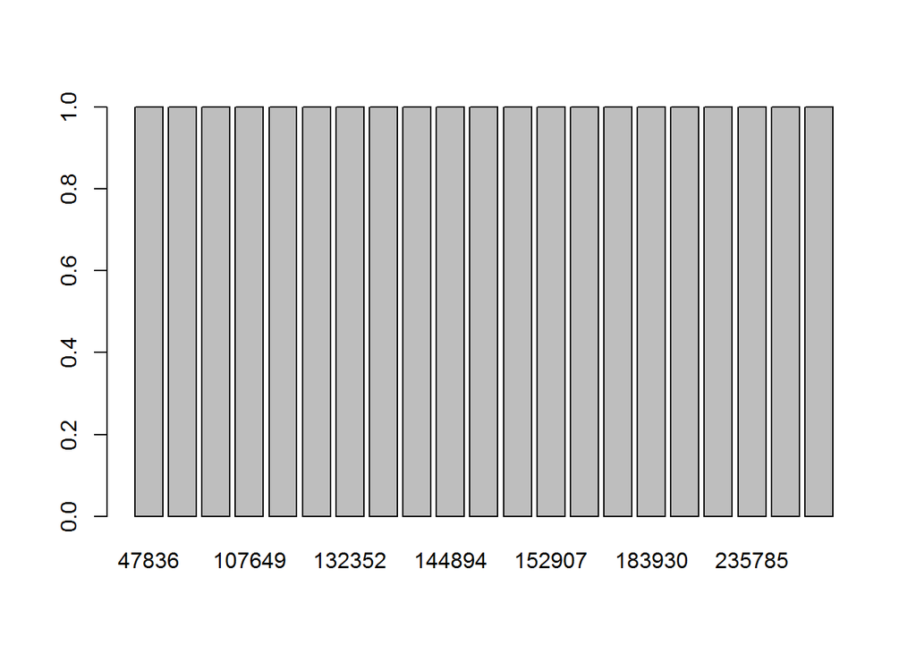

```r
#grafico de frecuencia
barplot(table(madrid$Poblacion))
```

```r
#resumen de los valores mas significativos
summary(madrid$Poblacion)
```

```
##    Min. 1st Qu.  Median    Mean 3rd Qu.    Max.
##   47836  119011  145268  153420  183930  248220
```

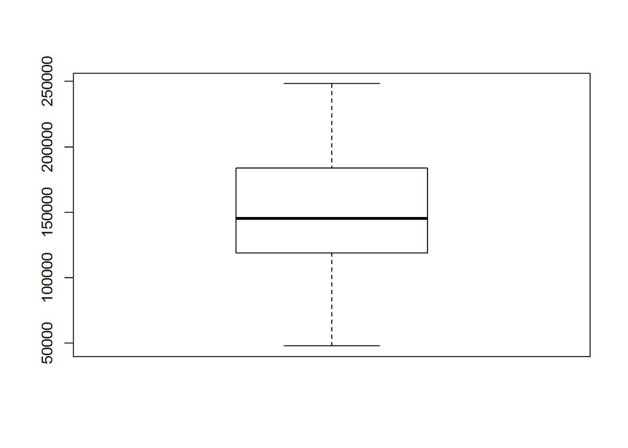

```r
#grafica boxplot
boxplot(madrid$Poblacion)
```

```r
#Media Aritmetica
Media_Poblacion<-mean(madrid$Poblacion)
#Mediana
Mediana_Poblacion<-median(madrid$Poblacion)
#Media Recortada
Media_Recortada_Poblacion<-mean(madrid$Poblacion, trim=0.05)
#Desviación estándar
Desviacion_estandar_Poblacion<-sd(madrid$Poblacion)
#Rango Intercuartilico (RIC)
RIC_Poblacion<-IQR(madrid$Poblacion)
#Desviación Absoluta Respecto de la Mediana
Desviacion_Absoluta_Mediana_Poblacion<-mad(madrid$Poblacion)
#Tabla
kable(rbind(Media_Poblacion,Mediana_Poblacion,Media_Recortada_Poblacion,
Desviacion_estandar_Poblacion,RIC_Poblacion,
Desviacion_Absoluta_Mediana_Poblacion))
```

| Media_Poblacion | 153420.19 |
| --- | --- |
| Mediana_Poblacion | 145268.00 |
| Media_Recortada_Poblacion | 153987.79 |
| Desviacion_estandar_Poblacion | 55464.68 |
| RIC_Poblacion | 64919.00 |
| Desviacion_Absoluta_Mediana_Poblacion | 40672.17 |

**NumCentSan**

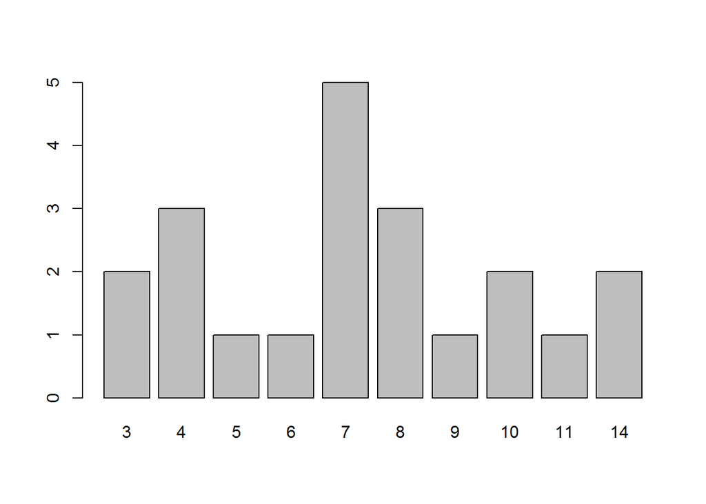

```r
#grafico de frecuencia
barplot(table(madrid$NumCentSan))
```

```r
#resumen de los valores mas significativos
summary(madrid$NumCentSan)
```

```
##    Min. 1st Qu.  Median    Mean 3rd Qu.    Max.
##   3.000   5.000   7.000   7.429   9.000  14.000
```

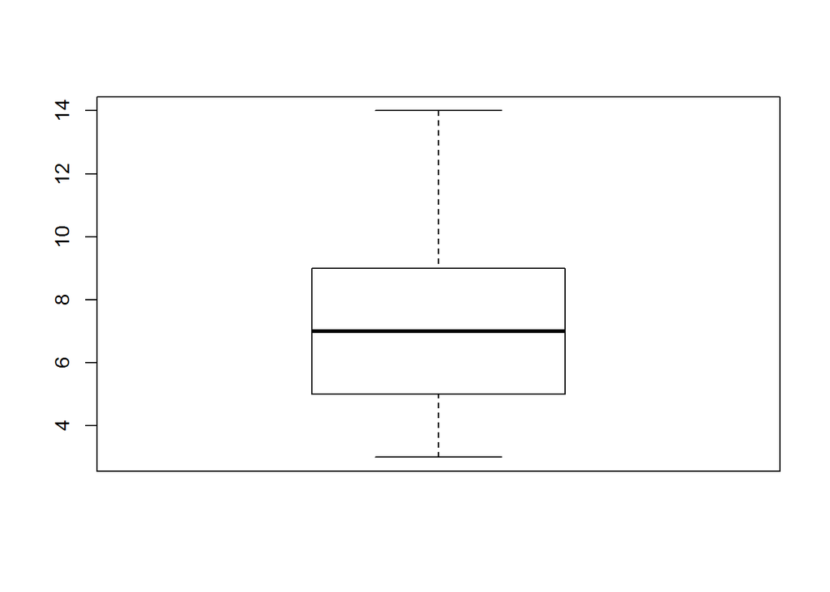

```r
#grafica boxplot
boxplot(madrid$NumCentSan)
```

```r
#Media Aritmetica
Media_NumCentSan<-mean(madrid$NumCentSan)
#Mediana
Mediana_NumCentSan<-median(madrid$NumCentSan)
#Media Recortada
Media_Recortada_NumCentSan<-mean(madrid$NumCentSan, trim=0.05)
#Desviación estándar
Desviacion_estandar_NumCentSan<-sd(madrid$NumCentSan)
#Rango Intercuartilico (RIC)
RIC_NumCentSan<-IQR(madrid$NumCentSan)
#Desviación Absoluta Respecto de la Mediana
Desviacion_Absoluta_Mediana_NumCentSan<-mad(madrid$NumCentSan)
#Tabla
kable(rbind(Media_NumCentSan,Mediana_NumCentSan,Media_Recortada_NumCentSan,
Desviacion_estandar_NumCentSan,RIC_NumCentSan,
Desviacion_Absoluta_Mediana_NumCentSan))
```

| Media_NumCentSan | 7.428571 |
| --- | --- |
| Mediana_NumCentSan | 7.000000 |
| Media_Recortada_NumCentSan | 7.315790 |
| Desviacion_estandar_NumCentSan | 3.155494 |
| RIC_NumCentSan | 4.000000 |
| Desviacion_Absoluta_Mediana_NumCentSan | 2.965200 |

No existe ningún distrito que pueda descatar por encima de otros por tener mayor número de centros de salud, ni tampoco hay ningún registro que pueda destacar por tener un múmero de centros de salud muy inferior a los demas. El 50% de los distritos tiene entre 5 y 9 centros de salud. La distribucción de esta variable es asimétrica.

**NumAparc**

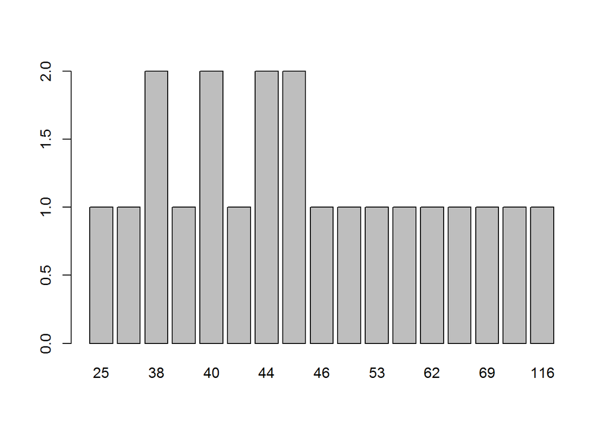

```r
#grafico de frecuencia
barplot(table(madrid$NumAparc))
```

```r
#resumen de los valores mas significativos
summary(madrid$NumAparc)
```

```
##    Min. 1st Qu.  Median    Mean 3rd Qu.    Max.
##   25.00   40.00   45.00   50.81   55.00  116.00
```

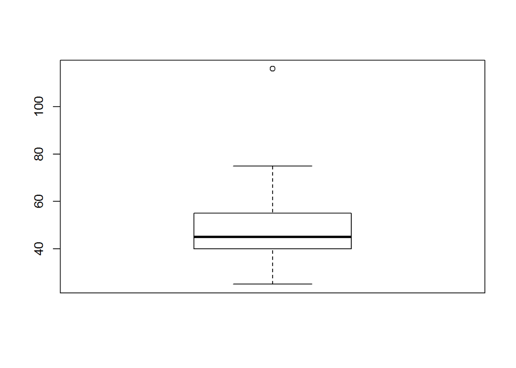

```r
#grafica boxplot
boxplot(madrid$NumAparc)
```

```r
#Media Aritmetica
Media_NumAparc<-mean(madrid$NumAparc)
#Mediana
Mediana_NumAparc<-median(madrid$NumAparc)
#Media Recortada
Media_Recortada_NumAparc<-mean(madrid$NumAparc, trim=0.05)
#Desviación estándar
Desviacion_estandar_NumAparc<-sd(madrid$NumAparc)
#Rango Intercuartilico (RIC)
RIC_NumAparc<-IQR(madrid$NumAparc)
#Desviación Absoluta Respecto de la Mediana
Desviacion_Absoluta_Mediana_NumAparc<-mad(madrid$NumAparc)
#Tabla
kable(rbind(Media_NumAparc,Mediana_NumAparc,Media_Recortada_NumAparc,
Desviacion_estandar_NumAparc,RIC_NumAparc,
Desviacion_Absoluta_Mediana_NumAparc))
```

| Media_NumAparc | 50.80952 |
| --- | --- |
| Mediana_NumAparc | 45.00000 |
| Media_Recortada_NumAparc | 48.73684 |
| Desviacion_estandar_NumAparc | 19.10659 |
| RIC_NumAparc | 15.00000 |
| Desviacion_Absoluta_Mediana_NumAparc | 10.37820 |

Hay un distrito que tiene un número mas elevado del resto de número de aparcamientos de bicis. El número de aparcamientos de bici en los distritos se encuentran entren los 25 y 70 aproximadamente. Situando al 50% de los distritos entre 40 y 57 aproximadamente.

**Numptolim**

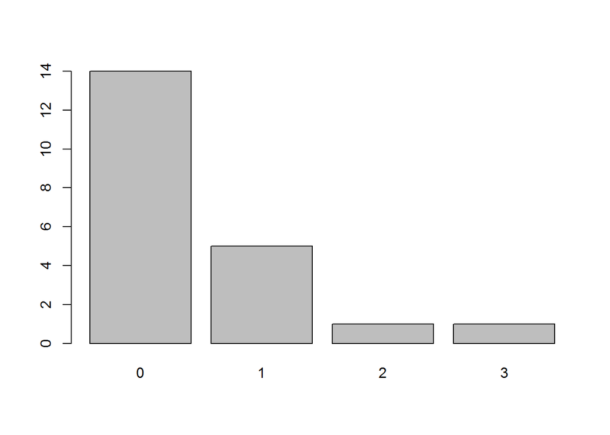

```r
#grafico de frecuencia
barplot(table(madrid$Numptolim))
```

```r
#resumen de los valores mas significativos
summary(madrid$Numptolim)
```

```
##    Min. 1st Qu.  Median    Mean 3rd Qu.    Max.
##  0.0000  0.0000  0.0000  0.4762  1.0000  3.0000
```

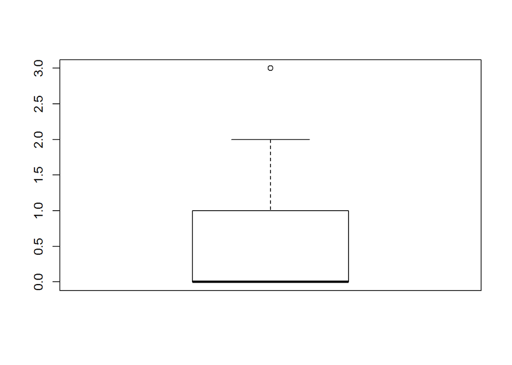

```r
#grafica boxplot
boxplot(madrid$Numptolim)
```

```r
#Media Aritmetica
Media_Numptolim<-mean(madrid$Numptolim)
#Mediana
Mediana_Numptolim<-median(madrid$Numptolim)
#Media Recortada
Media_Recortada_Numptolim<-mean(madrid$Numptolim, trim=0.05)
#Desviación estándar
Desviacion_estandar_Numptolim<-sd(madrid$Numptolim)
#Rango Intercuartilico (RIC)
RIC_Numptolim<-IQR(madrid$Numptolim)
#Desviación Absoluta Respecto de la Mediana
Desviacion_Absoluta_Mediana_Numptolim<-mad(madrid$Numptolim)
#Tabla
kable(rbind(Media_Numptolim,Mediana_Numptolim,Media_Recortada_Numptolim,
Desviacion_estandar_Numptolim,RIC_Numptolim,
Desviacion_Absoluta_Mediana_Numptolim))
```

| Media_Numptolim | 0.4761905 |
| --- | --- |
| Mediana_Numptolim | 0.0000000 |
| Media_Recortada_Numptolim | 0.3684211 |
| Desviacion_estandar_Numptolim | 0.8135753 |
| RIC_Numptolim | 1.0000000 |
| Desviacion_Absoluta_Mediana_Numptolim | 0.0000000 |

La mayoria de los distritos todavía no tienen disponible este servicio. Unicamente un único distrito tiene 3 puntos para este servicio.

**Numptosrecargas**

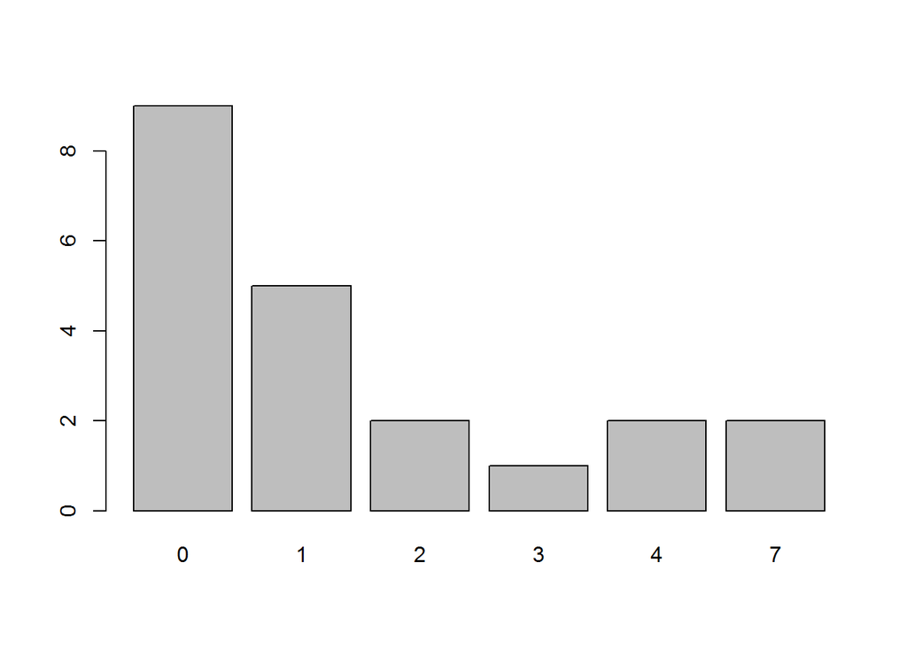

```r
#grafico de frecuencia
barplot(table(madrid$Numptosrecargas ))
```

```r
#resumen de los valores mas significativos
summary(madrid$Numptosrecargas )
```

```
##    Min. 1st Qu.  Median    Mean 3rd Qu.    Max.
##   0.000   0.000   1.000   1.619   2.000   7.000
```

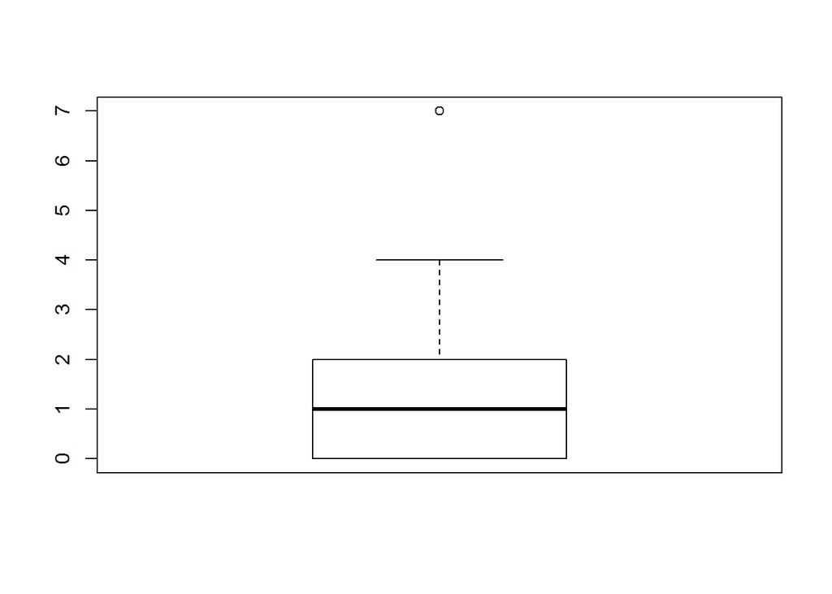

```r
#grafica boxplot
boxplot(madrid$Numptosrecargas )
```

```r
#Media Aritmetica
Media_Numptosrecargas <-mean(madrid$Numptosrecargas )
#Mediana
Mediana_Numptosrecargas <-median(madrid$Numptosrecargas )
#Media Recortada
Media_Recortada_Numptosrecargas <-mean(madrid$Numptosrecargas , trim=0.05)
#Desviación estándar
Desviacion_estandar_Numptosrecargas <-sd(madrid$Numptosrecargas )
#Rango Intercuartilico (RIC)
RIC_Numptosrecargas <-IQR(madrid$Numptosrecargas )
#Desviación Absoluta Respecto de la Mediana
Desviacion_Absoluta_Mediana_Numptosrecargas <-mad(madrid$Numptosrecargas )
#Tabla
kable(rbind(Media_Numptosrecargas ,Mediana_Numptosrecargas ,Media_Recortada_Numptosrecargas ,
Desviacion_estandar_Numptosrecargas ,RIC_Numptosrecargas ,
Desviacion_Absoluta_Mediana_Numptosrecargas ))
```

| Media_Numptosrecargas | 1.619048 |
| --- | --- |
| Mediana_Numptosrecargas | 1.000000 |
| Media_Recortada_Numptosrecargas | 1.421053 |
| Desviacion_estandar_Numptosrecargas | 2.201731 |
| RIC_Numptosrecargas | 2.000000 |
| Desviacion_Absoluta_Mediana_Numptosrecargas | 1.482600 |

En este caso al igual que el anterior no todos los distritos gozan de este servicio. Unicamente hay dos distritos que tienen 7 puntos de recargas. El 50% de los distritos se encuentran entre 0 y 2 puntos.

**NumInmu**

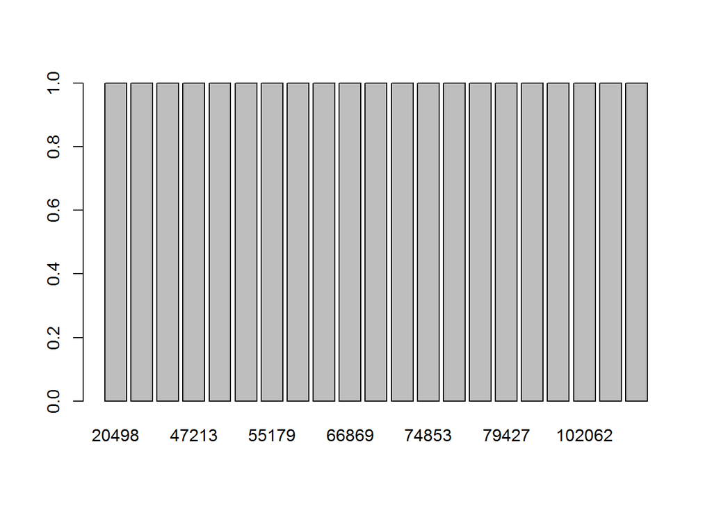

```r
#grafico de frecuencia
barplot(table(madrid$NumInmu ))
```

```r
#resumen de los valores mas significativos
summary(madrid$NumInmu )
```

```
##    Min. 1st Qu.  Median    Mean 3rd Qu.    Max.
##   20498   54365   72997   69881   79427  108410
```